# Statistical Analysis with R

## Content

1. R and RStudio
   - architecture
   - console
   - workspace
   - packages
2. Data types
   - vectors, factors, data frames and lists
   - subsetting
3. Functions
   - arguments
   - help pages
4. Formulas
   - the `~` symbol
5. R Markdown

## R and RStudio

## R

Language and environment for statistical computing and graphics.

**Language**

- vocabulary: what are the function names?
- semantics: what do the functions do?
- syntax: how to use these functions?

**Environment**

- virtual space with a collection of objects, variables and functions

## RStudio

An integrated development environment for R

**Additional functionality**

- editor with syntax highlighting
- integrated help functions
- debugging tools
- plotting tools
- and much more

## RStudio openingsscreen

[figure not shown]

## Console

Executes commands and shows output

[figure not shown]

## Global environment (workspace)

User-defined objects and loaded R packages

- objects are made with the assignment operator `<-` (`Ctrl + Alt + -`)

[figure not shown]

## R Packages

**Base R packages**

- `stats`, `graphics`, …, `base`
- automatically loaded in workspace

**User-contributed packages** (+/- 20,000)

- need to be installed (only once)
  - via the menu: `Tools - Install package...`
  - via the prompt: `install.package("name package")`
- need to be loaded in work space at each new session
  - `library(<name package>)`

Install the package `tidyverse`

## Data types

## Most common

1. vectors
   - collection of elements of the same class
   - classes can be numeric, character, logical or factor
2. data frames
   - cases and variables (a collection of vectors)
   - used for statistical analysis
3. lists
   - collection of objects of any class
   - used to collect output of functions

## Vectors

**A single entity consisting of a collection of things** (R manual)

- vectors have a `class`
- main function to make vectors is `c()`
- `factor`s are a special class of vectors

| class | elements | example |
| --- | --- | --- |
| `numeric` | numbers | `c(1, 2, 3)` |
| `character` | strings | `c("a", "b", "c")` |
| `logical` | `TRUE/FALSE` | `c(TRUE, FALSE)` |
| `factor` | levels | `factor(c("a", "b", "c"))` |

## Vectors are atomic

You can’t mix classes within a vector

```r
x <- c("cat", "dog")        # class is character
y <- c(1, 2)                # class is numeric
z <- c(TRUE, FALSE)         # class is logical

class(x)
[1] "character"

class(y)
[1] "numeric"

class(z)
[1] "logical"

class(c(x, y, z)) # mix up different classes
[1] "character"
```

## Factors

Factors are vectors for categorical variables

- the categories are called `levels`
- R treats `factor` differently from `character` vectors

```r
summary(x)
   Length     Class      Mode
        2 character character

summary(as.factor(x))
cat dog
  1   1
```

Make `x` and run `plot(x)` and `plot(factor(x))`

## Vector generating functions

```r
c(1, 2, 3, 4, 5)         # collects elements in vector
[1] 1 2 3 4 5

seq(from = 1, to = 5)    # a sequence of integers
[1] 1 2 3 4 5

1:5                      # shorthand for seq
[1] 1 2 3 4 5

seq(1, 5, by = 0.5)      # sequence with steps of 0.5
[1] 1.0 1.5 2.0 2.5 3.0 3.5 4.0 4.5 5.0

rep(1:5, times = 2)      # repeats the vector 1:5 twice (times is default)
 [1] 1 2 3 4 5 1 2 3 4 5

rep(1:5, each = 2)       # repeats the elements in 1:5 twice
 [1] 1 1 2 2 3 3 4 4 5 5
```

Display the vector `c(1, 2, 2, 3, 3, 3)` using `rep().`

## Naming vector elements

Assign a name to a vector element with `=`

```r
(v <- c(dog = 1, cat = 2, rabbit = 3))
   dog    cat rabbit
     1      2      3
```

Never use the assignment operator for function arguments!

```r
c(dog <- 1, cat <- 2, rabbit <- 3)
[1] 1 2 3
```

## Data frames

Two-dimensional array with observations and variables

- `...` represents vectors of the same length separated by a comma

```r
data.frame(..., row.names = NULL)
```

Data frames are not atomic, variables can be of different class

```r
(d <- data.frame(x, y, z))
    x y     z
1 cat 1  TRUE
2 dog 2 FALSE

sapply(d, class)
          x           y           z
"character"   "numeric"   "logical"
```

## Lists

Collection of R objects of any kind (either named or unnamed)

```r
(my_list <- list(x = x,     # list element 1 with vector x is named x
                 y,         # list element 2 with vector y is not named
                 c = d,     # list element 3 with data frame d is named c
                 f = mean)) # list element 4 is the function mean
```

```
$x
[1] "cat" "dog"

[[2]]
[1] 1 2

$c
    x y     z
1 cat 1  TRUE
2 dog 2 FALSE

$f
function (x, ...)
UseMethod("mean")
<bytecode: 0x000002995ac4add0>
<environment: namespace:base>
```

## Subsetting

Extracting elements from a data object

- `vector[i]`: `i` a vector with numbers or names (in parenthesis)
- `dataframe[i, j]`: `i` refers to the cases, `j` to the variables
- `dataframe$variable`: extracts the variable from the data frame
- `list[[i]]`: `i` a scalar or name (in parenthesis)
- `list$name`: name of the list element

Extract function `f` with arguments `1:5` from `my_list`

```r
my_list$f(1:5)
[1] 3
```

## Functions

## Arguments

Functions perform operations on objects

- function have arguments

```r
mean(x, trim = 0, na.rm = FALSE)
```

- `x` is the data object for which to compute the mean
- `trim` for the proportion of cases to be trimmed (default is 0)
- `na.rm` to remove missing values (coded `NA`)

Compute the mean of the vector `c(1, 2, 3, NA)`

## Help pages of functions

Always check the help of a function

[figure not shown]

## Formulas

## The `~` symbol

Formulas are characterized by the `~` symbol, e.g.

`y ~ x`

means `y` as a function of `x`

Predicting `mpg` from `disp`:

```r
lm(mpg ~ disp, mtcars)

Call:
lm(formula = mpg ~ disp, data = mtcars)

Coefficients:
(Intercept)         disp
   29.59985     -0.04122
```

## R Markdown

## Authoring documents

The practicals are made in R Markdown

- make exercises in an `.Rmd` file with text, R code and R output
- convert to HTML document

R markdown also used for making

- slides, websites, dashboards, etc.

## R Markdown universe

[figure not shown]

## Rmd template (source mode)

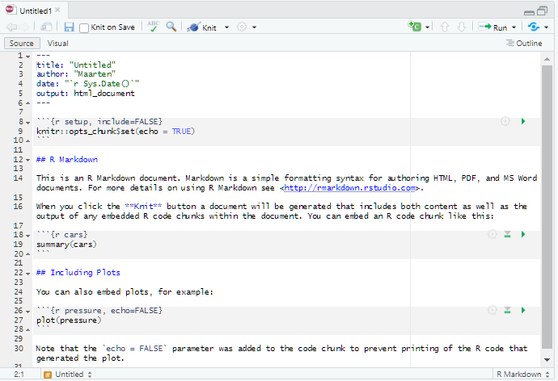

## Rmd template (visual mode)

[figure not shown]

## Structure Rmd files

R chunk without chunk options

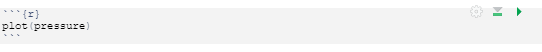

Chunk option to hide the code of this chunk

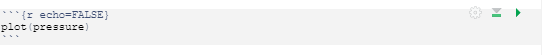